# Mask Use Mandates

Chris Troeger

7/28/2020

## Summary of mandates

The mask mandate dataset includes 337 mandates from 216 locations. One of the challenges is defining the target population, as shown in the first table below. There is some inconsistency in the coding for the target population and there are a wide array of targeted groups in the mandates.

**Types of targeted populations listed in mandate**

One challenge is that there are a huge number of unique target populations in the extraction sheet. A full list is provided at the end of the document. Some of the inconsistency is from how the target populations are extracted and some is inherent in the many types. Some examples are *General public*, *Public spaces*, *All areas*, *Grocery shops*, *Indoor public spaces*, *Cafes*, *Churches*, *Maritime workers*, *Service personnel*, etc.

The current logic is that each location can only have a single mandate so I have implemented a way to rank the available mandates by location. If a location only has a single target population, that is kept. If a location has a mandate for ‘General public’ or some variation, that is kept. Finally, if a location has ‘public’ in the target population column, that is kept. After subsetting based on that, some locations still have multiple mandates so I keep the earliest implemented mandate. The resulting dataset is 189 location-mandates.

For example, in the table below, I am currently keeping rows 1, 4, and 5. Keeping row 1 because it is the most general of the target populations. Row 4 because it is the only mandate for Peru in this example. Row 5 because it is the earliest mandate for the general public. **These are examples**

Example of the way that the mask mandates are extracted and saved

| Row number | Location | Target population | Date implemented |
| --- | --- | --- | --- |
| 1 | Colorado | General public | 2020-06-23 |
| 2 | Colorado | Outdoor spaces | 2020-06-23 |
| 3 | Colorado | Transit | 2020-06-20 |
| 4 | Peru | Indoor business | 2020-07-10 |
| 5 | Ghana | General public | 2020-07-01 |
| 6 | Ghana | Public spaces | 2020-07-12 |

**Enforcement measures**

The mask mandate dataset has a similar challenge in how enforcement policies are defined. The table below shows the count by enforcement type groupings. Currently these are defined as:

- If the enforcement column contains the expression ‘fine’ then the enforcement is a **Fine**
  - Unique enforcement types include *Fines | Fine: 20000 Kenyan shillings; or 6 month jail term | Fine | Fine: up to 30,000 PLN | Fine of £100, or £50 if you pay the fine within 14 days | Fine of £60 (which doubles for each subsequent offence up to a maximum of £1920 | Possible €100 to €600 fine | Fine of SR1,000 for individuals, SR10,000 for businesses | Fine of 3000 rupees (18 USD) | Fine between LE 300 and LE 5,000 | Fine of K5,000 | Fines of 500 to 1,000 euros | 5,000 RSD fine | Civil fine up to $1,000 and criminal prosecution for Reckless Endangerment (class A misdemeanor) | A person who knowingly and willfully violates this Order is guilty of a misdemeanor and on conviction is subject to imprisonment not exceeding one year or a fine not exceeding $5,000 or both. | $300 civil fine | Businesses or individuals can have their licenses revoked by state, Also Class C misdemeanor: punishable by up to 30 days in jail, a fine of up to $1,250, or both | fine up to $1,000 or confinement in jail for a term up to 180 days. | up to a year in jail and a $2,500 fine | Up to 90 days in jail / $100 fine | Misdemeanor and <$100 fine | Fined 2000 ALL.*
- If the enforcement column contains the expression ‘detention’ or ‘arrest’ then the enforcement is **Detention**
  - Unique enforcement types include *Up to detention | Arrest/Detention | Arrest.*
- If the enforcement column contains the expression ‘legal’, ‘penalty’, or ‘misdemeanor’ then the enforcement is **Penalty**
  - Unique enforcement types include *Legal action | Misdemeanor | Civil or criminal penalties | Criminal penalty | Civil, criminal, and administrative penalties | Businesses not enforcing: citation; Customer not complying: trespassing | (quote) A violation of this Order may be construed to be a violation of any such license, permit and other authorization to which pertinent penalties may be assessed. Pursuant to 37-B M.R.S.A. section 786, this Order may also be enforced by law enforcement as necessary. | Local public health agencies and law enforcement should focus their enforcement of this Directive on education, providing warnings and education about the risk of transmission, while reserving the imposition of penalties, trespass enforcement, and other formal enforcement mechanisms for only the most egregious, repeat violations that put the public at risk. | General “criminal prosecution and civil penalties” | Businesses: citation; Patrons: trespassing if won’t leave | Citations or warnings.*
- If the enforcement column contains the expression ‘none’, ‘not applicable’, or ‘no penalty’ then the enforcement is **None**
  - Unique enforcement types include *Not applicable | None stated | Not stated | None Stated.*
- All other types are coded as **Other/unknown**
  - Unique enforcement types include *Not known | Other | Forced labor: cleaning | Police enforcement | No entry | NA | Denied entrance | Sanction | (quote) This Executive Order may be enforced by State and local law enforcement pursuant to, inter alia, Section 7, Section 15, Section 18, and Section 19 of the Illinois Emergency Management Agency Act, 20 ILCS 3305 | (quote) As currently permitted pursuant to state law, the Attorney General, county attorneys, and district attorneys enforcing this order should use their discretion and consider the totality of the circumstances as they determine appropriate enforcement actions | Loss of access to business’ services | Decline entry.*

Summary of how I have defined enforcement/penalties for non-compliance

| Enforcement type | Mandates (n) |
| --- | --- |
| Detention | 9 |
| Fine | 41 |
| None | 132 |
| Other/unknown | 128 |
| Penalty | 27 |

## Regressions

The mandate data are merged onto the Facebook, Yougov, and Premise mask use survey data by location and date. Mandates are a binary indicator for if a mandate is in effect by location-date. I assume that after a mandate is implemented, it is not lifted.

I am running these as mixed effects (ME) models with a random intercept by location_id.

There are 20835 location-days of mask use data, among which 7150 are days with a mask mandate in effect for this analysis.

**Mixed-effects regression where (1-maskuse) is the dependent variable**

Mixed-effects

|  | Estimate | Std. Error | t value |
| --- | --- | --- | --- |
| Intercept | 0.455 | 0.013 | 34.701 |
| Mandate | -0.067 | 0.003 | -21.547 |

Date covariate

|  | Estimate | Std. Error | t value |
| --- | --- | --- | --- |
| Intercept | -0.044 | 0.433 | -0.102 |
| Mandate | -0.069 | 0.003 | -20.578 |
| Date | 0.000 | 0.000 | 1.155 |

Location-day variable

|  | Estimate | Std. Error | t value |
| --- | --- | --- | --- |
| Intercept | 0.452 | 0.013 | 34.186 |
| Mandate | -0.074 | 0.003 | -22.594 |
| Location index (1:n) | 0.000 | 0.000 | 6.746 |

Time measured as days since first case by location

|  | Estimate | Std. Error | t value |
| --- | --- | --- | --- |
| Intercept | 0.453 | 0.013 | 34.145 |
| Mandate | -0.069 | 0.003 | -20.598 |
| Days since 1st case | 0.000 | 0.000 | 1.220 |

Interaction with penalty

|  | Estimate | Std. Error | t value |
| --- | --- | --- | --- |
| Intercept | 0.519 | 0.020 | 26.102 |
| Detention | -0.073 | 0.020 | -3.687 |
| Fine | -0.116 | 0.009 | -12.285 |
| None | -0.072 | 0.005 | -15.320 |
| Other/unknown | -0.023 | 0.007 | -3.124 |
| Penalty | -0.158 | 0.024 | -6.628 |

More narrowly defined penalty. Criminal/civil penalties is the combination of the ‘Detention’ and ‘Penalty’ categories above

|  | Estimate | Std. Error | t value |
| --- | --- | --- | --- |
| Intercept | 0.519 | 0.020 | 26.225 |
| Criminal/civil penalty | -0.108 | 0.015 | -7.073 |
| Fine | -0.116 | 0.009 | -12.279 |
| None | -0.072 | 0.005 | -15.312 |
| Other/unknown | -0.023 | 0.007 | -3.131 |

Civil or criminal penalty, Fines, anything else. Criminal and civil penalties combine ‘Detention’ and ‘Penalty’ above and None or other is a combination of ‘None’ and ‘Other/unknown’ above.

|  | Estimate | Std. Error | t value |
| --- | --- | --- | --- |
| Intercept | 0.523 | 0.019 | 27.345 |
| Criminal/civil penalty | -0.108 | 0.015 | -7.063 |
| Fine | -0.116 | 0.009 | -12.263 |
| None or other | -0.058 | 0.004 | -14.532 |

Location-day variable and penalty interaction

|  | Estimate | Std. Error | t value |
| --- | --- | --- | --- |
| Intercept | 0.516 | 0.020 | 26.020 |
| Location index (1:n) | 0.001 | 0.000 | 16.114 |
| Detention | -0.106 | 0.020 | -5.380 |
| Fine | -0.145 | 0.009 | -15.322 |
| None | -0.104 | 0.005 | -20.629 |
| Other/unknown | -0.057 | 0.008 | -7.578 |
| Penalty | -0.164 | 0.023 | -6.978 |

Location-day, daily infections, and penalty interaction

|  | Estimate | Std. Error | t value |
| --- | --- | --- | --- |
| Intercept | 0.521 | 0.020 | 26.604 |
| Location index (1:n) | 0.001 | 0.000 | 18.221 |
| Daily infections | 0.000 | 0.000 | -11.611 |
| Detention | -0.111 | 0.020 | -5.680 |
| Fine | -0.146 | 0.009 | -15.529 |
| None | -0.107 | 0.005 | -21.268 |
| Other/unknown | -0.057 | 0.007 | -7.656 |
| Penalty | -0.164 | 0.023 | -7.034 |

Location-day, daily incidence, and penalty interaction

|  | Estimate | Std. Error | t value |
| --- | --- | --- | --- |
| Intercept | 0.528 | 0.020 | 26.983 |
| Location index (1:n) | 0.001 | 0.000 | 17.567 |
| Daily incidence | -78.117 | 7.299 | -10.702 |
| Detention | -0.110 | 0.020 | -5.597 |
| Fine | -0.143 | 0.009 | -15.187 |
| None | -0.104 | 0.005 | -20.717 |
| Other/unknown | -0.061 | 0.007 | -8.111 |
| Penalty | -0.157 | 0.023 | -6.740 |

Location-day, daily infections, and narrow penalty definitions

|  | Estimate | Std. Error | t value |
| --- | --- | --- | --- |
| Intercept | 0.526 | 0.019 | 27.852 |
| Location index (1:n) | 0.001 | 0.000 | 18.370 |
| Daily infections | 0.000 | 0.000 | -11.480 |
| Criminal or civil penalty | -0.133 | 0.015 | -8.853 |
| Fine | -0.147 | 0.009 | -15.538 |
| None or other | -0.093 | 0.004 | -21.124 |

Any penalty interaction

|  | Estimate | Std. Error | t value |
| --- | --- | --- | --- |
| Intercept | 0.524 | 0.019 | 27.348 |
| Mandate: any penalty | -0.114 | 0.008 | -14.132 |
| Mandate: no penalty | -0.058 | 0.004 | -14.534 |

Any penalty interaction and smoothed daily infections

|  | Estimate | Std. Error | t value |
| --- | --- | --- | --- |
| Intercept | 0.528 | 0.019 | 27.856 |
| Daily infections | 0.000 | 0.000 | -7.849 |
| Mandate: any penalty | -0.112 | 0.008 | -13.966 |
| Mandate: no penalty | -0.056 | 0.004 | -14.063 |

Location-day variable and any penalty interaction

|  | Estimate | Std. Error | t value |
| --- | --- | --- | --- |
| Intercept | 0.521 | 0.019 | 27.167 |
| Location index (1:n) | 0.001 | 0.000 | 16.279 |
| Mandate: any penalty | -0.141 | 0.008 | -17.416 |
| Mandate: no penalty | -0.091 | 0.004 | -20.564 |

Location-day, daily infections, and any penalty interaction

|  | Estimate | Std. Error | t value |
| --- | --- | --- | --- |
| Intercept | 0.526 | 0.019 | 27.854 |
| Daily infections | 0.000 | 0.000 | -11.489 |
| Location index (1:n) | 0.001 | 0.000 | 18.357 |
| Mandate: any penalty | -0.143 | 0.008 | -17.722 |
| Mandate: no penalty | -0.093 | 0.004 | -21.117 |

Location-day, daily infections

[output not shown]

Sensitivity analysis, use earliest imposed mandate, even if it is not general public

|  | Estimate | Std. Error | t value |
| --- | --- | --- | --- |
| Intercept | 0.46 | 0.013 | 34.906 |
| Mandate | -0.08 | 0.003 | -24.045 |

Sensitivity analysis, linear regression (fixed effects only), narrow penalty definition

|  | Estimate | Std. Error | t value | Pr(>\|t\|) |
| --- | --- | --- | --- | --- |
| Intercept | 0.606 | 0.006 | 107.787 | 0 |
| Civil or criminal | -0.133 | 0.013 | -10.649 | 0 |
| Fine | -0.187 | 0.010 | -17.912 | 0 |
| None or other | -0.221 | 0.006 | -34.656 | 0 |

Sensitivity analysis, linear regression (fixed effects only), any penalty

|  | Estimate | Std. Error | t value | Pr(>\|t\|) |
| --- | --- | --- | --- | --- |
| Intercept | 0.606 | 0.006 | 107.706 | 0 |
| Any penalty | -0.166 | 0.009 | -18.666 | 0 |
| No penalty | -0.221 | 0.006 | -34.630 | 0 |

**Mixed-effects regression where mask use always is the dependent variable**

$maskuse \sim mandate + (1|location)$

Mask use is the proportion of people that self-report always wearing a mask while outside their home.

Mixed effects

|  | Estimate | Std. Error | t value |
| --- | --- | --- | --- |
| Intercept | 0.545 | 0.013 | 41.497 |
| Mandate | 0.067 | 0.003 | 21.547 |

Date covariate

|  | Estimate | Std. Error | t value |
| --- | --- | --- | --- |
| Intercept | 1.044 | 0.433 | 2.412 |
| Mandate | 0.069 | 0.003 | 20.578 |
| Date | 0.000 | 0.000 | -1.155 |

Location-day variable

|  | Estimate | Std. Error | t value |
| --- | --- | --- | --- |
| Intercept | 0.548 | 0.013 | 41.528 |
| Mandate | 0.074 | 0.003 | 22.594 |
| Location index (1:n) | 0.000 | 0.000 | -6.746 |

Interaction with penalty

|  | Estimate | Std. Error | t value |
| --- | --- | --- | --- |
| Intercept | 0.481 | 0.020 | 24.190 |
| Detention | 0.073 | 0.020 | 3.687 |
| Fine | 0.116 | 0.009 | 12.285 |
| None | 0.072 | 0.005 | 15.320 |
| Other/unknown | 0.023 | 0.007 | 3.124 |
| Penalty | 0.158 | 0.024 | 6.628 |

Interaction with penalty and location-day index

|  | Estimate | Std. Error | t value |
| --- | --- | --- | --- |
| Intercept | 0.484 | 0.020 | 24.400 |
| Location index (1:n) | -0.001 | 0.000 | -16.114 |
| Detention | 0.106 | 0.020 | 5.380 |
| Fine | 0.145 | 0.009 | 15.322 |
| None | 0.104 | 0.005 | 20.629 |
| Other/unknown | 0.057 | 0.008 | 7.578 |
| Penalty | 0.164 | 0.023 | 6.978 |

**I also wanted to run the analysis as a panel to account for the time series in a different way. To do so, I had to create a new variable for the index because we have different sources of mask use data that sometimes had the same location-date. This new variable is location_source. Sources include Facebook, Yougov, Premise, etc.**

The panel set up is a random effects model with an index by (date, loc source).

Including this location_source in the mixed effects model does not seem to meaningfully affect the coefficient on mandates ($maskuse \sim mandate + (1|loc source)$). However, the panel regression set up does seem to affect the coefficient on mask mandates, decreasing it pretty substantially.

**Tables for coefficients in panel regression**

Panel model, indexed by date and location-source

|  | Estimate | Std. Error | z-value | Pr(>\|z\|) |
| --- | --- | --- | --- | --- |
| Intercept | 0.585 | 0.004 | 148.588 | 0 |
| Mandate | 0.014 | 0.003 | 4.151 | 0 |

And really changing the values for the coefficients on the penalties

Panel model, interaction with penalty type

|  | Estimate | Std. Error | z-value | Pr(>\|z\|) |
| --- | --- | --- | --- | --- |
| Intercept | 0.394 | 0.005 | 72.022 | 0.000 |
| Detention | 0.197 | 0.014 | 13.950 | 0.000 |
| Fine | 0.187 | 0.010 | 18.418 | 0.000 |
| None | 0.162 | 0.007 | 23.892 | 0.000 |
| Other/unknown | 0.282 | 0.007 | 41.098 | 0.000 |
| Penalty | -0.014 | 0.021 | -0.688 | 0.491 |

Which is the better regression set up? Any alternatives?

**Here are a few plots showing the distribution of mask use data**

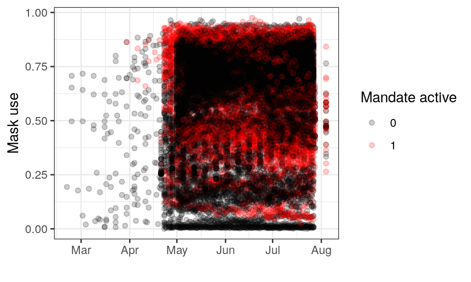

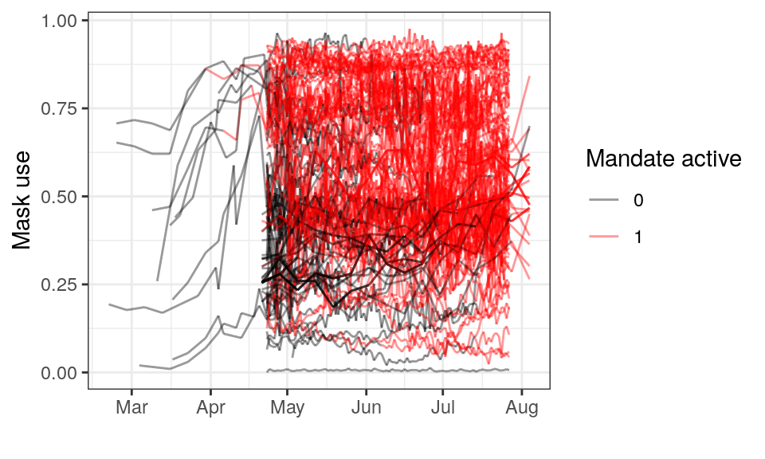

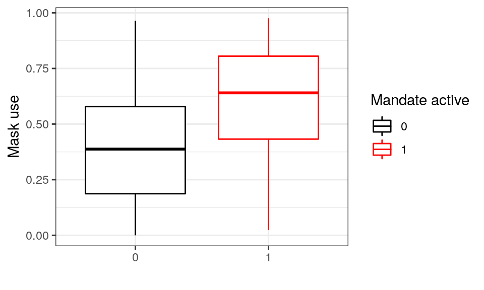

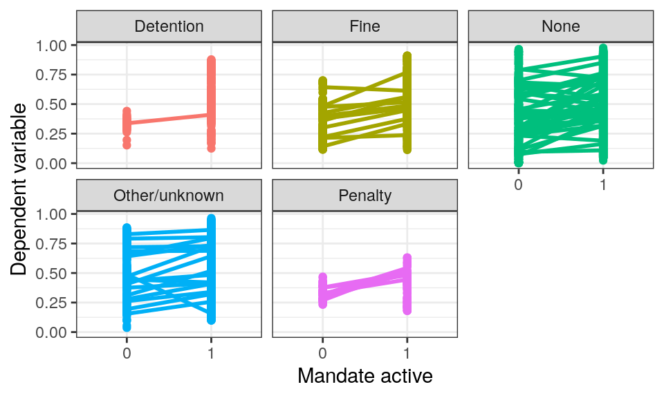

**Results from the mixed-effects regression where dependent variable is $\Delta maskuse / (1-maskuse)$ (not shown)**

## Full list of target populations in mask mandates

*General public, All public spaces, on buses, Public transport, All areas, Grocery shops, All indoor public places, Indoor events, Demonstrations, Government buildings, Delivery persons, general public, Public transport, Over 12s, all offices, Public spaces, Public places, businesses and common areas of residential buildings, Mosques, Public places, public places, Outdoor spaces, Cafe, restaurant staff, pubic transport, hospitals, pharmacies, Indoor public spaces, all travellers, Transport and closed public spaces, Public, public transport, public transport, shopping, public transport, retail, markets, Public areas, Ferry, All citizens, Caregivers, any symptoms, vendors and shoppers, Public transport, Shops, Those without disabilities, over five, or not alone indoors, All persons, Markets, commercial businesses, Public/Private Transit, General Public; All public spaces; Public transit, Salon and Barbershop employees, General Public, Health care workers, Airport, Public transit; Businesses, Travelers (14 days), Employees in craft sector, Public transit, Events >20, Stores; Public transit; Sea voyages, Markets; Mosques, Stores; Public transit, General public; Public transit; Private transit; Religious institutions; Maritime transport, Public transit; Private transit; Gatherings, General public; Public transit; Private transit; Gatherings, Truck drivers, General public; Public transit; Businesses, General public; Public transit, Churches, School, Entertainment, Businesses, All travellers from high-risk countries, Agricultural workers, Some public spaces, Asthmatics, Caregivers, ill person or COVID-19 positive, Public places other than pools and restaurants, General public; businesses, public transport, and government, General public, transport staff, Food industry, Martitime workers, NLT staff, Service personnel, Restaurants, Taxis, Performing arts, Indoor public places and transportation, Airline and airport staff, Bus and car travel, Restaurant staff, Markets, Hospitals, Public Transport, Public Transport, Airplanes, Visitors, General public; Businesses, Schools; Businesses; Public transit, Public transit; Private transit, Indoor public spaces; Public transit, General public; Public transit; Private transit, Air travel, Schools, Businesses; Indoor public spaces, Indoor public areas, Public transit; Indoor public spaces, Businesses; Public transit; Private transit, General public; Gatherings; Public transit, Genearl public, All indoor spaces, transportation, and outdoor spaces if group is 10 or more, Some businesses, and at gatherings with non-household members, All indoor spaces, Government offices and facilities, Indoor spaces and only applies to people 11 years or older, All businesses, transportation, and outdoor public spaces, Ride share programs, taxis, and private transportation vehicles (recommended for public transportation but not required), All public transportation and private transportation (e.g. rideshare, taxis), Essential businesses, Indoor public spaces; Ourdoor public spaces; Businesses; Public transit, Customers, All public spaces; Customers, All public spaces; Customers; Public transit, Customers; Public transit, Enclosed public spaces, Customers; Outdoor gatherings, Customers; Indoor gatherings, Customers; All indoor settings, All outdoor public spaces, All Public Spaces; Public transit; Businesses, All Public Spaces, State Buildings, Public transportation, All indoor spaces and transportation, All indoor public spaces, All Public Spaces; Public transit, Indoor public spaces; Businesses; Public transit, Indoor settings and retail, Indoors, public transport, Employees at outdoor arenas; Employees at pools, Massage; Tattoo; Salons, Businesses; Government Buildings, NA*.